# Exercise 10

Author

Filled In During Class

## Preliminaries

Download the CustomerMixedDatesData.csv under Week 10 from Canvas. After downloading the file into your computer, complete the script below to load customer_data into your R env’t.

```r
library(tidyverse)
customer_data <- read_csv("data/CustomerMixedDatesData.csv")
head(customer_data)
```

```
# A tibble: 6 × 5
  customer_id account_creation_date submission_date approval_date
  <chr>       <date>                <chr>           <chr>
1 CUST-0001   2020-01-10            08-07-20        June 29, 2021
2 CUST-0002   2020-01-13            11-21-20        July 05, 2021
3 CUST-0003   2020-03-03            12-04-20        July 06, 2021
4 CUST-0004   2020-04-26            12-29-20        July 13, 2021
5 CUST-0005   2020-04-29            03-11-21        August 05, 2021
6 CUST-0006   2020-05-29            03-14-21        August 19, 2021
# ℹ 1 more variable: records_creation_date <chr>
```

## Basic Data Documentation

**customer_id:** unique customer identifier ID

**account_creation_date:** ISO8601 formatted date

**submission_date:** date in MM-DD-YY format (e.g., 08-07-20)

**approval_date:** date in Month DD, YYYY format (e.g., June 29, 2021)

**records_creation_date:** date in Mon DD, YYYY format (e.g., Nov 12, 2021)

## Date Time Reference Table

You will need this table for one or more of the tasks below (this image is also provided within the Lecture 10 slides):

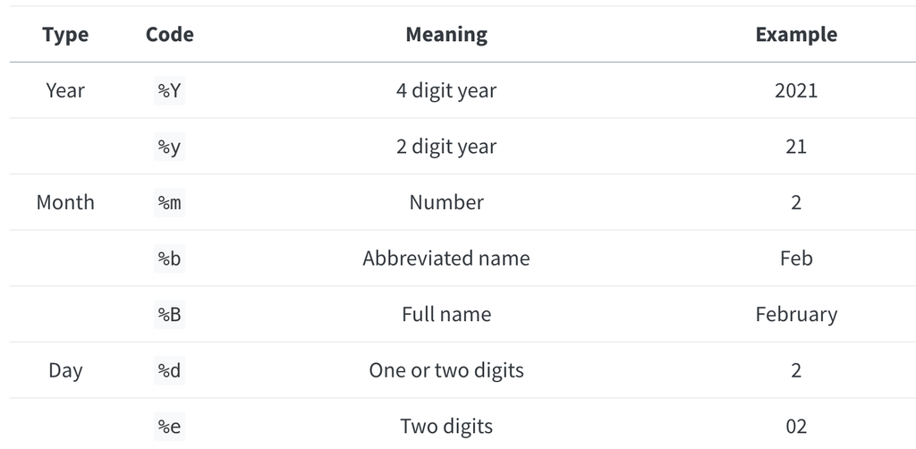

## Task 1

customer_data was loaded but submission_date, approval_date, and records_creation_date were loaded into R as chr (string). Before proceeding to Task 2, complete the table below by using the reference table provided above.

Complete this table (see Slide 11 from [https://jmtfeliciano.github.io/DATA412Fall2024/Data412612Lecture10](https://jmtfeliciano.github.io/DATA412Fall2024/Data412612Lecture10#11) as a reference):

| Variables we need to work on | Example | Date Time General Equivalent |
| --- | --- | --- |
| **submission_date** | date in MM-DD-YY format (e.g., 08-07-20) | “%m-%e-%y” |
| **approval_date** | date in Month DD, YYYY format (e.g., June 29, 2021) | “%B %e, %Y” |
| **records_creation_date** | date in Mon DD, YYYY format (e.g., Nov 12, 2021) | “%b %e, %Y” |

## Task 2

Complete the code below to create customer_data_v2 that loads submission_date, approval_date, and records_creation_date as date type.

```r
# complete or correct the code below
customer_data_v2<- read_csv("data/CustomerMixedDatesData.csv",
                           col_types = cols(submission_date =  col_date("%m-%e-%y"),
                                            approval_date = col_date("%B %e, %Y"),
                                            records_creation_date = col_date("%b %e, %Y")
                                            ))

head(customer_data_v2)
```

```
# A tibble: 6 × 5
  customer_id account_creation_date submission_date approval_date
  <chr>       <date>                <date>          <date>
1 CUST-0001   2020-01-10            2020-08-07      2021-06-29
2 CUST-0002   2020-01-13            2020-11-21      2021-07-05
3 CUST-0003   2020-03-03            2020-12-04      2021-07-06
4 CUST-0004   2020-04-26            2020-12-29      2021-07-13
5 CUST-0005   2020-04-29            2021-03-11      2021-08-05
6 CUST-0006   2020-05-29            2021-03-14      2021-08-19
# ℹ 1 more variable: records_creation_date <date>
```

## Task 3

Using method 2 from Lecture 10, complete the code below to transform customer_data (loaded at the beginning of this Quarto document) into customer_data_v3 by transforming submission_date, approval_date, and records_creation_date columns from char (string) type to data type.

```r
# complete or correct the code below
customer_data_v3 <- customer_data |>
  mutate(submission_date = mdy(submission_date),
         approval_date = mdy(approval_date),
         records_creation_date = mdy(records_creation_date))

glimpse(customer_data_v3)
```

```
Rows: 10
Columns: 5
$ customer_id           <chr> "CUST-0001", "CUST-0002", "CUST-0003", "CUST-000…
$ account_creation_date <date> 2020-01-10, 2020-01-13, 2020-03-03, 2020-04-26,…
$ submission_date       <date> 2020-08-07, 2020-11-21, 2020-12-04, 2020-12-29,…
$ approval_date         <date> 2021-06-29, 2021-07-05, 2021-07-06, 2021-07-13,…
$ records_creation_date <date> 2021-11-12, 2022-01-13, 2022-01-21, 2022-02-05,…
```

## Task 4

Download the apple_stock_prices.rds file under Week 10 from Canvas. After downloading the file into your computer, load the file into your computer as apple_stock_prices in your R env’t. Print a subset of this data using head() or glimpse(). Note: This table contains end-of-day stock prices for Apple.

```r
# Place your code below
apple_stock_prices <- read_rds("data/apple_stock_prices.rds")

glimpse(apple_stock_prices)
```

```
Rows: 2,768
Columns: 2
$ closing_day_price <dbl> 7.643214, 7.656429, 7.534643, 7.520714, 7.570714, 7.…
$ date              <date> 2010-01-04, 2010-01-05, 2010-01-06, 2010-01-07, 201…
```

## Task 5

Using data you generated under Task 4, create a line graph using ggplot below with date on the x-axis.

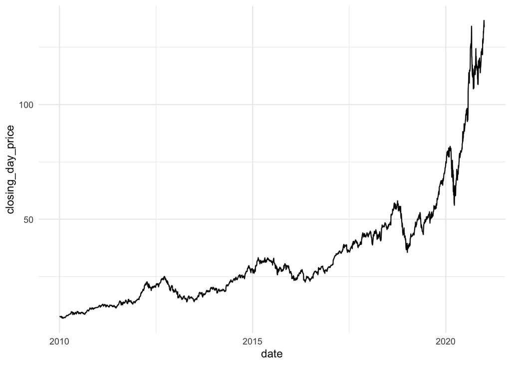

```r
# Place your code below
ggplot(apple_stock_prices,
       aes(x = date, y = closing_day_price)) +
  geom_line() +
  theme_minimal() # extra: to remove ugly grey background
```

## Task 6

Create a subset of apple_stock_prices that only includes data between 2012 and 2013 (Hint: Slide 19 of Lecture 10). Save the data into the R env’t. Name it however you want but make sure it follows best practices in R. Then using that data subset, create a line graph below:

```r
# Place your code below
apple_stock_prices_v2 <- apple_stock_prices |>
  filter(date >= ymd("2012-01-01") & date <= ymd("2013-12-31"))

head(apple_stock_prices_v2)
```

```
  closing_day_price       date
1          14.68679 2012-01-03
2          14.76571 2012-01-04
3          14.92964 2012-01-05
4          15.08571 2012-01-06
5          15.06179 2012-01-09
6          15.11571 2012-01-10
```

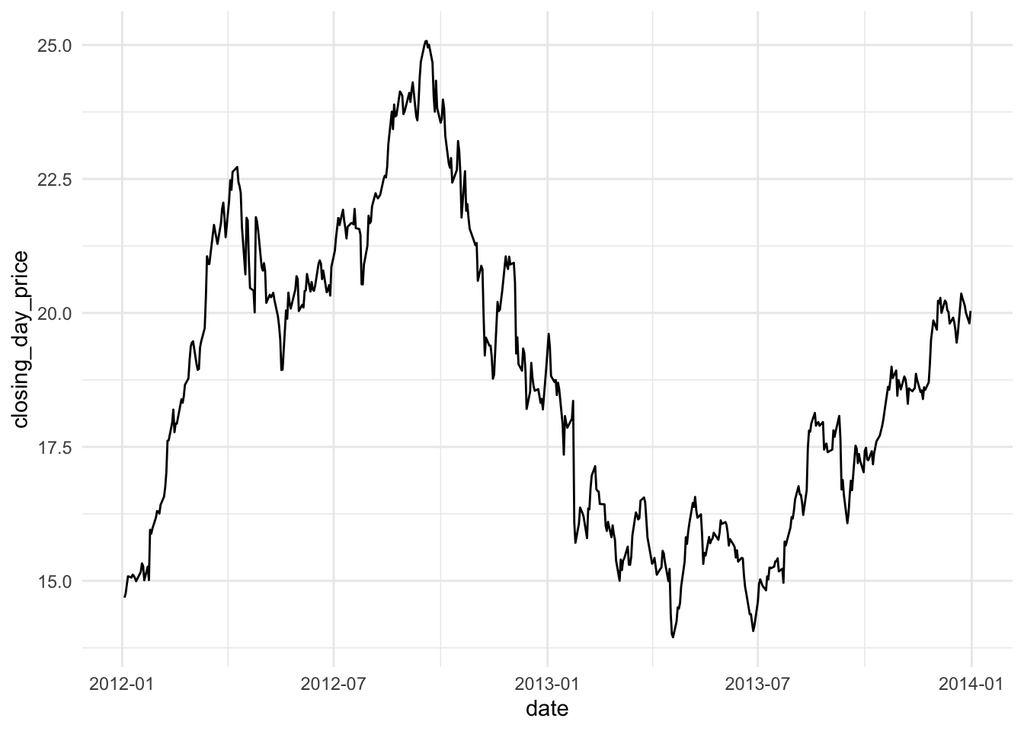

```r
ggplot(apple_stock_prices_v2,
       aes(x = date, y = closing_day_price)) +
  geom_line() +
  theme_minimal() # extra: to remove ugly grey background
```

## Task 6 extra (optional)

This will not be covered in homework or midterm.

Suppose you want to highlight a particular day in your line graph by adding a vertical line for a specific date. Copy the code you generated for the original Task 6 then add the following customization to your code:

> geom_vline(xintercept = ymd(“2012-09-19”), color = “blue”, linetype=“dotted”)

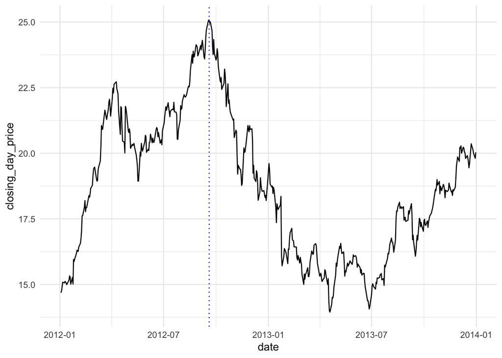

```r
# Place your code below
ggplot(apple_stock_prices_v2,
       aes(x = date, y = closing_day_price)) +
  geom_line() +
  theme_minimal() +
  geom_vline(xintercept = ymd("2012-09-19"), color = "blue", linetype="dotted")
```

## Task 7

Note: For questions 7.a.-7.c., feel free to use this R chunk below to assist you in answering the questions.

```r
# Place your code below
apple_stock_prices |>
  arrange(desc(closing_day_price)) |>
  head()
```

```
  closing_day_price       date
1            136.69 2020-12-28
2            134.87 2020-12-29
3            134.18 2020-09-01
4            133.72 2020-12-30
5            131.97 2020-12-24
6            131.88 2020-12-22
```

```r
apple_stock_prices |>
  arrange(closing_day_price) |>
  head()
```

```
  closing_day_price       date
1          6.858929 2010-02-04
2          6.859286 2010-01-29
3          6.932857 2010-02-08
4          6.954643 2010-02-01
5          6.968571 2010-02-10
6          6.980714 2010-02-05
```

```r
apple_stock_prices |>
  filter(date == ymd("2012-06-01"))
```

```
  closing_day_price       date
1          20.03536 2012-06-01
```

```r
# this one works without the ymd but not best practice
# many in the R community uses this anyways
apple_stock_prices |>
  filter(date == "2012-06-01")
```

```
  closing_day_price       date
1          20.03536 2012-06-01
```

**Question 7.a.:** What is the highest end-of-day stock price ever achieved by Apple stocks within the data set and what is the record date for that stock price?

> **Your response: Highest price is** 136.69 which occurred on 2020-12-28.

**Question 7.b.:** What is the lowest end-of-day stock prices ever achieved by Apple stocks within the data set and what is the record date for that stock price?

> **Your response:** The lowest price is 6.858929 which occurred on 2010-02-04.

**Question 7.c:** What is the Apple stock price for June 1, 2012?

> **Your response: The price for June 1st 2012 is** 20.03536

## Task 7 extra (optional)

This will not be covered in homework or midterm. You don’t have to type anything. Just run the following script that uses slice(which.min()) and slice(which.max()) which is a more streamline way of getting min or max values not taught in your book:

```r
# a short-cut way to get the row where closing_day_price is the lowest
apple_stock_prices |>
  slice(which.min(closing_day_price))
```

```
  closing_day_price       date
1          6.858929 2010-02-04
```

```r
# a short-cut way to get the row where closing_day_price is the highest
apple_stock_prices |>
  slice(which.max(closing_day_price))
```

```
  closing_day_price       date
1            136.69 2020-12-28
```

## Task 8.a.

Suppose you are a data scientist who assists a federal program that delivers low interest loans to small businesses. You are given a file (application_data_2023.csv which is on canvas). The file contains the application date, the loan request amount, and loan application unique identifier code. Each row represents a unique loan, and there are multiple loans for each day.

Using R and the file given to you, create a line graph with the date on the x–axis and the number of applications for each day.

```r
# Place your code below
application_data <- read_csv("data/application_data_2023.csv")
application_data_v2 <- application_data |>
  group_by(application_date) |>
  summarise(daily_application_count = n())

head(application_data_v2)
```

```
# A tibble: 6 × 2
  application_date daily_application_count
  <date>                             <int>
1 2023-01-01                            25
2 2023-01-02                            31
3 2023-01-03                            24
4 2023-01-04                            20
5 2023-01-05                            25
6 2023-01-06                            20
```

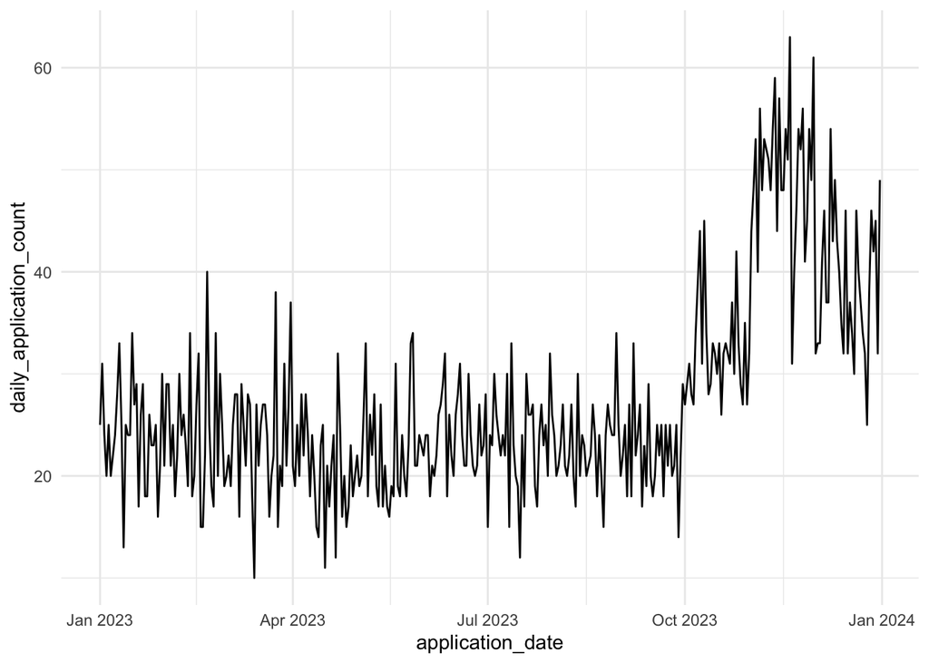

```r
ggplot(application_data_v2,
       aes(x = application_date, y = daily_application_count)) +
  geom_line() +
  theme_minimal()
```

## Task 8.b.

> **Question:** Suppose your office is understaffed and your budget allows you to hire federal contractors next year to assist your office in processing applications for a maximum of three months. Based on historical demand (i.e., using insights you generated in Task 8a), which three months would you recommend in 2025 for contractor support and why?

> **Your response:** Recommend resources for Oct-Dec based on prior data

## Task 8.c.

> **Task and Question:** Using R and the csv file given to you under Task 8.a., create a line graph with the date on the x–axis and the total dollars for each day. Given this new graph, does it change the recommendation you created under Task 8.b.?

> **Your response:** No, federal dollars are concentrated also in Oct-Dec.

```r
# Place your code below
application_data_v3 <- application_data |>
  group_by(application_date) |>
  summarise(total_dollars = sum(applied_dollars, na.rm = T))

head(application_data_v3)
```

```
# A tibble: 6 × 2
  application_date total_dollars
  <date>                   <dbl>
1 2023-01-01          240967956.
2 2023-01-02          244716834.
3 2023-01-03          240106714.
4 2023-01-04          220576268.
5 2023-01-05          218095456.
6 2023-01-06          217489294.
```

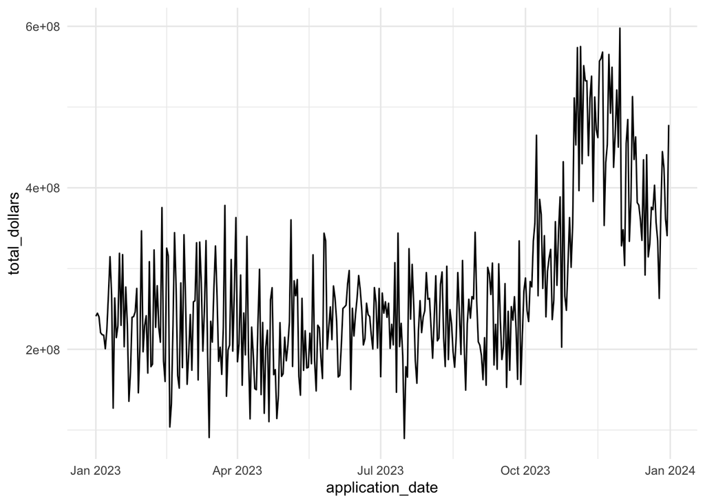

```r
ggplot(application_data_v3,
       aes(x = application_date, y = total_dollars)) +
  geom_line() +
  theme_minimal()
```

## Task 8.d. extra (optional)

Copy the ggplot code from 8c. This time, add the following ggplot customization at the end:

> scale_y_continuous(labels = scales::comma)

Compare your 8.d. graph to your 8.c. graph. How are they different? What does the 8.d. customization code accomplishes?

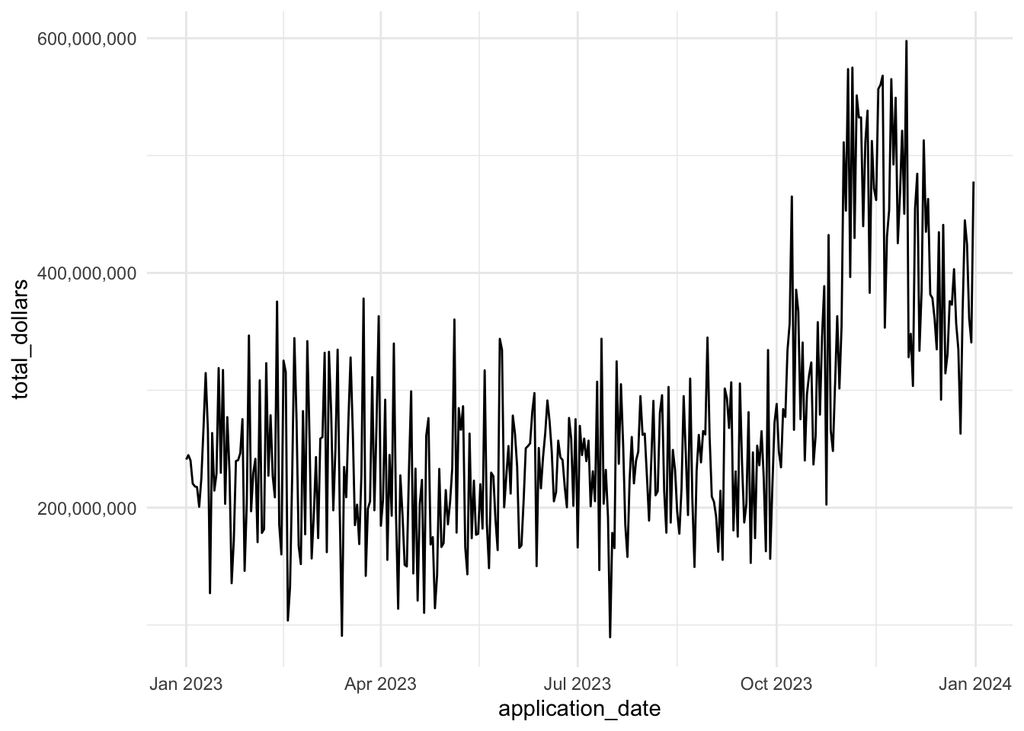

```r
# Place your code below
ggplot(application_data_v3,
       aes(x = application_date, y = total_dollars)) +
  geom_line() +
  theme_minimal() +
  scale_y_continuous(labels = scales::comma)
```